# Tugas 2

[figure not shown]

# Prediksi Permintaan Produk di Indomaret untuk Optimisasi Stok Barang

# Pendahuluan

## Latar Belakang

Indomaret, sebagai salah satu jaringan minimarket terbesar di Indonesia, melayani kebutuhan masyarakat dengan berbagai kategori produk. Dengan ribuan gerai yang tersebar di berbagai daerah, pengelolaan stok menjadi salah satu tantangan utama dalam menjaga ketersediaan produk di rak tanpa terjadi kelebihan stok yang berpotensi menimbulkan kerugian.

Permintaan barang yang berfluktuasi karena faktor musiman, promosi, lokasi geografis, dan preferensi pelanggan seringkali menyulitkan manajemen dalam memprediksi kebutuhan stok. Jika stok terlalu sedikit, akan ada risiko kehilangan peluang penjualan (lost sales). Sebaliknya, jika stok terlalu banyak, produk dapat menumpuk di gudang dan menimbulkan biaya penyimpanan yang tinggi atau bahkan kerugian akibat kedaluwarsa, terutama untuk produk yang sensitif waktu seperti makanan dan minuman.

Untuk mengatasi tantangan ini, prediksi permintaan barang berbasis time series menjadi solusi yang relevan. Dengan memanfaatkan data historis penjualan, model prediksi dapat membantu memproyeksikan kebutuhan stok secara lebih akurat. Penelitian ini bertujuan untuk mengembangkan model prediksi yang dapat digunakan oleh Indomaret untuk mendukung pengambilan keputusan terkait perencanaan stok yang optimal.

## Tujuan

Penelitian ini bertujuan untuk mengembangkan sebuah model prediksi yang mampu memperkirakan permintaan produk di Indomaret berdasarkan data historis penjualan. Dengan adanya model ini, diharapkan manajemen dapat memahami pola-pola permintaan barang di berbagai gerai Indomaret, sehingga perencanaan stok barang dapat dilakukan secara lebih akurat.

Selain itu, penelitian ini juga bertujuan untuk membantu Indomaret dalam mengoptimalkan stok barang dengan meminimalkan risiko kelebihan dan kekurangan stok. Dengan memprediksi permintaan secara tepat, perusahaan dapat menghindari kerugian akibat barang yang tidak terjual atau kekurangan stok yang berpotensi menyebabkan kehilangan peluang penjualan (lost sales).

Penelitian ini juga bertujuan untuk mencari model prediksi yang terbaik dalam memproyeksikan permintaan barang. Dengan mencoba berbagai pendekatan dan metode analisis, penelitian ini akan mengidentifikasi model yang paling efektif dan akurat untuk digunakan dalam konteks operasional Indomaret.

Hasil dari penelitian ini diharapkan dapat memberikan rekomendasi strategis kepada manajemen Indomaret untuk meningkatkan efisiensi operasional, khususnya dalam pengelolaan gudang dan distribusi barang. Rekomendasi ini diharapkan dapat mendukung pengambilan keputusan yang lebih baik dalam perencanaan stok, penyimpanan, dan pendistribusian produk di seluruh jaringan Indomaret.

## Rumusan Masalah

Apa model yang terbaik untuk memprediksi permintaan produk di Indomaret? Penelitian ini akan mengidentifikasi dan mengevaluasi berbagai model prediksi yang dapat digunakan untuk memproyeksikan permintaan produk dengan akurat. Beberapa model yang akan diuji termasuk regresi linear, random forest, dan Support Vector Regression. Penelitian ini akan menguji akurasi masing-masing model dan menentukan model yang paling efektif untuk konteks operasional Indomaret

# Data understanding

Pada pekerjaan kali ini saya akan melakukan forecasting untuk prediksi permintaan produk di indomaret untuk optimisasi stok, Dataset yang saya gunakan adalah dataset "Indomaret_sales" yang saya ambil dari Kaggle berikut link dataset nya https://www.kaggle.com/datasets/firmanhermawan/data-sales-simulasi-indomaret

```python
import pandas as pd
    import numpy as np
    import matplotlib.pyplot as plt
    import seaborn as sns
    from tabulate import tabulate
```

```python
from google.colab import drive
    drive.mount('/content/drive')
```

## Menampilkan data

```python
# Path ke dataset
    dataset_path = '/content/drive/MyDrive/PSD/Dataset_indomaret_sales.csv'

    # Membaca dataset
    df = pd.read_csv(dataset_path)

    # Tampilkan 5 baris pertama
    print(df.head())
```

```
  Transaction_ID        Date           Product_Name         Category  \
    0          T0001  2024-10-06   Pepsodent Toothpaste    Personal Care
    1          T0002  2024-10-01  ABC Kecap Manis 620ml        Groceries
    2          T0003  2024-10-01     Lifebuoy Body Wash    Personal Care
    3          T0004  2024-10-06               Milo 1kg           Drinks
    4          T0005  2024-10-03         Indomie Goreng  Instant Noodles

       Units_Sold Unit_Price  Total_Revenue Store_Location Payment_Method
    0         NaN      15000       675000.0        Jakarta           Cash
    1        60.0      18000      1080000.0        Jakarta           Card
    2        17.0      25000       425000.0          Medan           Cash
    3        95.0      90000      8550000.0        Bandung           Cash
    4        30.0       3000        90000.0       Surabaya           Card
```

```python
# Membuat Data Understanding
    data_understanding = {
        'No': [1, 2, 3, 4, 5, 6, 7, 8, 9],
        'Fitur': [
            'Transaction_ID', 'Date', 'Product_Name', 'Category', 'Units_Sold',
            'Unit_Price', 'Total_Revenue', 'Store_Location', 'Payment_Method'
        ],
        'Tipe Data': [
            'string', 'datetime', 'string', 'string', 'numeric',
            'numeric', 'numeric', 'string', 'string'
        ],
        'Deskripsi': [
            'ID unik untuk setiap transaksi.',
            'Tanggal terjadinya transaksi.',
            'Nama produk yang dijual.',
            'Kategori produk.',
            'Jumlah unit yang terjual.',
            'Harga per unit produk.',
            'Total pendapatan dari transaksi.',
            'Lokasi toko tempat transaksi dilakukan.',
            'Metode pembayaran yang digunakan dalam transaksi.'
        ]
    }

    # Membuat DataFrame Data Understanding
    df_understanding = pd.DataFrame(data_understanding)

    # Menampilkan Data Understanding dalam format tabel
    print(tabulate(df_understanding, headers='keys', tablefmt='grid'))
```

```
+----+------+----------------+-------------+---------------------------------------------------+
    |    |   No | Fitur          | Tipe Data   | Deskripsi                                         |
    +====+======+================+=============+===================================================+
    |  0 |    1 | Transaction_ID | string      | ID unik untuk setiap transaksi.                   |
    +----+------+----------------+-------------+---------------------------------------------------+
    |  1 |    2 | Date           | datetime    | Tanggal terjadinya transaksi.                     |
    +----+------+----------------+-------------+---------------------------------------------------+
    |  2 |    3 | Product_Name   | string      | Nama produk yang dijual.                          |
    +----+------+----------------+-------------+---------------------------------------------------+
    |  3 |    4 | Category       | string      | Kategori produk.                                  |
    +----+------+----------------+-------------+---------------------------------------------------+
    |  4 |    5 | Units_Sold     | numeric     | Jumlah unit yang terjual.                         |
    +----+------+----------------+-------------+---------------------------------------------------+
    |  5 |    6 | Unit_Price     | numeric     | Harga per unit produk.                            |
    +----+------+----------------+-------------+---------------------------------------------------+
    |  6 |    7 | Total_Revenue  | numeric     | Total pendapatan dari transaksi.                  |
    +----+------+----------------+-------------+---------------------------------------------------+
    |  7 |    8 | Store_Location | string      | Lokasi toko tempat transaksi dilakukan.           |
    +----+------+----------------+-------------+---------------------------------------------------+
    |  8 |    9 | Payment_Method | string      | Metode pembayaran yang digunakan dalam transaksi. |
    +----+------+----------------+-------------+---------------------------------------------------+
```

Selanjutnya, untuk mengetahui jumlah baris dan kolom yang terdapat pada dataset, berikut adalah cara menampilkan jumlah baris dan kolom

```python
df = pd.read_csv('/content/drive/MyDrive/PSD/Dataset_indomaret_sales.csv')
    df.shape
```

```
(4000, 9)
```

Dari output diatas, dapat disimpulkan bahwa terdapat 4000 baris data dan 9 kolom

## Menentukan missing value

Missing value adalah hilangnya beberapa data yang telah diperoleh. Menangani missing value dengan tepat sangat penting untuk memastikan integritas dan akurasi analisis data. pada dataset indomaret selanjutnya dilakukan pengecekan missing value sebagi berikut:

```python
df = pd.read_csv('/content/drive/MyDrive/PSD/Dataset_indomaret_sales.csv')
    df.isnull().sum()
```

|  | 0 |
| --- | --- |
| Transaction_ID | 0 |
| Date | 0 |
| Product_Name | 0 |
| Category | 0 |
| Units_Sold | 133 |
| Unit_Price | 0 |
| Total_Revenue | 206 |
| Store_Location | 0 |
| Payment_Method | 0 |

**dtype:** int64

**Kesimpulan:** dapat dilihat bahwa terdapat missing value pada fitur "Unit_Sold" sebanyak 133, dan fitur "Total_Revenue" sebanyak 206

## Menangani Missing Value

Saya menggunakan metode dropna() untuk menghapus baris yang mengandung missing value dalam dataset saya, setelah menghapus baris yang terdapat missing value, berikutnya menyimpan dataset yang sudah bersih kedalam file CSV dan mengecek kembali bahwa tidak ada lagi missing value

```python
# Mengonversi kolom 'Unit_Price' menjadi numerik, mengganti nilai yang tidak valid menjadi NaN
    df['Unit_Price'] = pd.to_numeric(df['Unit_Price'], errors='coerce')

    # Menghapus baris yang mengandung missing value di kolom apapun, termasuk kolom 'Unit_Price'
    df_cleaned = df.dropna()

    # Menampilkan jumlah baris sebelum dan setelah penghapusan
    print(f"Dataset awal: {len(df)} baris")
    print(f"Dataset setelah penghapusan: {len(df_cleaned)} baris")

    # Menyimpan dataset yang sudah dibersihkan ke file CSV
    cleaned_path = '/content/drive/MyDrive/PSD/Dataset_indomaret_sales_cleaned.csv'
    df_cleaned.to_csv(cleaned_path, index=False)
    print(f"Dataset yang sudah dibersihkan disimpan di: {cleaned_path}")

    # Menampilkan jumlah missing value di setiap kolom setelah pembersihan
    print(df_cleaned.isnull().sum())
```

```
Dataset awal: 4000 baris
    Dataset setelah penghapusan: 3558 baris
    Dataset yang sudah dibersihkan disimpan di: /content/drive/MyDrive/PSD/Dataset_indomaret_sales_cleaned.csv
    Transaction_ID    0
    Date              0
    Product_Name      0
    Category          0
    Units_Sold        0
    Unit_Price        0
    Total_Revenue     0
    Store_Location    0
    Payment_Method    0
    dtype: int64
```

## Explorasi Data (Numeric)

Selanjutnya melakukan explorasi data numerik dengan rincian sebagai berikut:

```python
df = pd.read_csv('/content/drive/MyDrive/PSD/Dataset_indomaret_sales_cleaned.csv')
    df.describe()
```

|  | Units_Sold | Unit_Price | Total_Revenue |
| --- | --- | --- | --- |
| count | 3558.000000 | 3558.000000 | 3.558000e+03 |
| mean | 54.983418 | 21513.153457 | 1.178051e+06 |
| std | 26.111329 | 22049.882904 | 1.457805e+06 |
| min | 10.000000 | 2800.000000 | 3.000000e+04 |
| 25% | 33.000000 | 7000.000000 | 2.921250e+05 |
| 50% | 55.000000 | 12000.000000 | 6.645000e+05 |
| 75% | 77.000000 | 30000.000000 | 1.395000e+06 |
| max | 100.000000 | 90000.000000 | 9.000000e+06 |

**Kesimpulan:**

1. Unit_Sold (jumlah Unit terjual)
- Rata-rata (mean): 54.98 unit terjual per transaksi.
- Nilai minimal (min): 10 unit, yang menunjukkan ada transaksi dengan penjualan yang sangat sedikit.
- Nilai maksimal (max): 100 unit, menunjukkan ada transaksi dengan penjualan terbesar 100 unit.
- Standar deviasi (std): 26.11 unit, menunjukkan adanya variasi yang cukup besar dalam jumlah unit yang terjual
- 25% (Q1): 33 unit terjual, menunjukkan bahwa 25% transaksi memiliki penjualan kurang dari 33 unit.
- 50% (Q2, median): 55 unit terjual, menunjukkan bahwa 50% transaksi memiliki penjualan kurang dari atau sama dengan 55 unit.
- 75% (Q3): 77 unit terjual, menunjukkan bahwa 75% transaksi memiliki penjualan kurang dari atau sama dengan 77 unit.
2. Unit_Price (Harga Per Unit)
- Rata-rata (mean): 21,513.15, yang merupakan harga rata-rata per unit produk yang dijual.
- Nilai minimal (min): 2,800, yang menunjukkan harga termurah untuk sebuah produk adalah 2,800.
- Nilai maksimal (max): 90,000, yang menunjukkan harga termahal untuk sebuah produk adalah 90,000.
- Standar deviasi (std): 22,049.88, menunjukkan variasi harga yang sangat besar antar produk.
- 25% (Q1): 7,000, menunjukkan bahwa 25% produk memiliki harga per unit kurang dari 7,000.
- 50% (Q2, median): 12,000, menunjukkan bahwa 50% produk memiliki harga per unit kurang dari atau sama dengan 12,000.
- 75% (Q3): 30,000, menunjukkan bahwa 75% produk memiliki harga per unit kurang dari atau sama dengan 30,000.
3. Total_Revenue (Pendapatan Total)
- Rata-rata (mean): 1,178,051.00, yang menunjukkan rata-rata pendapatan total per transaksi.
- Nilai minimal (min): 30,000, menunjukkan ada transaksi dengan pendapatan total yang sangat rendah.
- Nilai maksimal (max): 9,000,000, yang menunjukkan ada transaksi dengan pendapatan total yang sangat tinggi.
- Standar deviasi (std): 1,457,805, yang menunjukkan variasi yang besar dalam pendapatan total antar transaksi.
- 25% (Q1): 292,125, menunjukkan bahwa 25% transaksi memiliki pendapatan total kurang dari 292,125.
- 50% (Q2, median): 664,500, menunjukkan bahwa 50% transaksi memiliki pendapatan total kurang dari atau sama dengan 664,500.
- 75% (Q3): 1,395,000, menunjukkan bahwa 75% transaksi memiliki pendapatan total kurang dari atau sama dengan 1,395,000.

## Distribusi Data

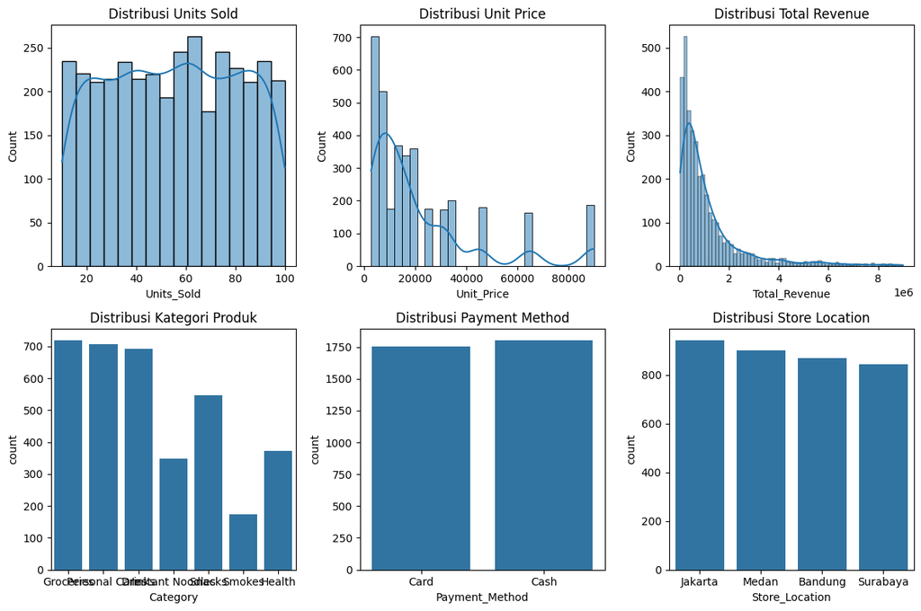

```python
# Menentukan ukuran plot
    plt.figure(figsize=(12, 8))

    # Menampilkan distribusi Jumlah Unit yang Terjual
    plt.subplot(2, 3, 1)
    sns.histplot(df['Units_Sold'], kde=True)
    plt.title('Distribusi Units Sold')

    # Menampilkan distribusi Harga per Unit
    plt.subplot(2, 3, 2)
    sns.histplot(df['Unit_Price'], kde=True)
    plt.title('Distribusi Unit Price')

    # Menampilkan distribusi Total Pendapatan
    plt.subplot(2, 3, 3)
    sns.histplot(df['Total_Revenue'], kde=True)
    plt.title('Distribusi Total Revenue')

    # Menampilkan distribusi Kategori Produk (sebagai kategori diskrit)
    plt.subplot(2, 3, 4)
    sns.countplot(x='Category', data=df)
    plt.title('Distribusi Kategori Produk')

    # Menampilkan distribusi Metode Pembayaran (sebagai kategori diskrit)
    plt.subplot(2, 3, 5)
    sns.countplot(x='Payment_Method', data=df)
    plt.title('Distribusi Payment Method')

    # Menampilkan distribusi Lokasi Toko (sebagai kategori diskrit)
    plt.subplot(2, 3, 6)
    sns.countplot(x='Store_Location', data=df)
    plt.title('Distribusi Store Location')

    # Menampilkan plot
    plt.tight_layout()
    plt.show()
```

## Menentukan Outlier

```python
# Menghitung Q1 (25%) dan Q3 (75%) untuk kolom yang dipilih
    Q1_unit_price = df_cleaned['Unit_Price'].quantile(0.25)
    Q3_unit_price = df_cleaned['Unit_Price'].quantile(0.75)
    IQR_unit_price = Q3_unit_price - Q1_unit_price

    Q1_units_sold = df_cleaned['Units_Sold'].quantile(0.25)
    Q3_units_sold = df_cleaned['Units_Sold'].quantile(0.75)
    IQR_units_sold = Q3_units_sold - Q1_units_sold

    Q1_total_revenue = df_cleaned['Total_Revenue'].quantile(0.25)
    Q3_total_revenue = df_cleaned['Total_Revenue'].quantile(0.75)
    IQR_total_revenue = Q3_total_revenue - Q1_total_revenue

    # Menetapkan batas bawah dan batas atas untuk masing-masing kolom
    lower_bound_unit_price = Q1_unit_price - 1.5 * IQR_unit_price
    upper_bound_unit_price = Q3_unit_price + 1.5 * IQR_unit_price

    lower_bound_units_sold = Q1_units_sold - 1.5 * IQR_units_sold
    upper_bound_units_sold = Q3_units_sold + 1.5 * IQR_units_sold

    lower_bound_total_revenue = Q1_total_revenue - 1.5 * IQR_total_revenue
    upper_bound_total_revenue = Q3_total_revenue + 1.5 * IQR_total_revenue

    # Menandai outlier
    outliers_unit_price = df_cleaned[(df_cleaned['Unit_Price'] < lower_bound_unit_price) | (df_cleaned['Unit_Price'] > upper_bound_unit_price)]
    outliers_units_sold = df_cleaned[(df_cleaned['Units_Sold'] < lower_bound_units_sold) | (df_cleaned['Units_Sold'] > upper_bound_units_sold)]
    outliers_total_revenue = df_cleaned[(df_cleaned['Total_Revenue'] < lower_bound_total_revenue) | (df_cleaned['Total_Revenue'] > upper_bound_total_revenue)]

    # Menampilkan hasil
    print(f"Outliers untuk 'Unit_Price': {outliers_unit_price.shape[0]} baris")
    print(f"Outliers untuk 'Units_Sold': {outliers_units_sold.shape[0]} baris")
    print(f"Outliers untuk 'Total_Revenue': {outliers_total_revenue.shape[0]} baris")

    # Menampilkan contoh outliers
    print("\nContoh Outliers 'Unit_Price':")
    print(outliers_unit_price.head())

    print("\nContoh Outliers 'Units_Sold':")
    print(outliers_units_sold.head())

    print("\nContoh Outliers 'Total_Revenue':")
    print(outliers_total_revenue.head())
```

```
Outliers untuk 'Unit_Price': 351 baris
    Outliers untuk 'Units_Sold': 0 baris
    Outliers untuk 'Total_Revenue': 317 baris

    Contoh Outliers 'Unit_Price':
       Transaction_ID        Date        Product_Name   Category  Units_Sold  \
    3           T0004  2024-10-06            Milo 1kg     Drinks        95.0
    24          T0025  2024-10-05            Milo 1kg     Drinks       100.0
    57          T0058  2024-10-04  Beras Maknyuss 5kg  Groceries        34.0
    60          T0061  2024-10-03            Milo 1kg     Drinks        20.0
    72          T0073  2024-10-01            Milo 1kg     Drinks        78.0

        Unit_Price  Total_Revenue Store_Location Payment_Method
    3      90000.0      8550000.0        Bandung           Cash
    24     90000.0      9000000.0        Jakarta           Cash
    57     65000.0      2210000.0       Surabaya           Card
    60     90000.0      1800000.0        Jakarta           Card
    72     90000.0      7020000.0          Medan           Card

    Contoh Outliers 'Units_Sold':
    Empty DataFrame
    Columns: [Transaction_ID, Date, Product_Name, Category, Units_Sold, Unit_Price, Total_Revenue, Store_Location, Payment_Method]
    Index: []

    Contoh Outliers 'Total_Revenue':
       Transaction_ID        Date        Product_Name       Category  Units_Sold  \
    3           T0004  2024-10-06            Milo 1kg         Drinks        95.0
    24          T0025  2024-10-05            Milo 1kg         Drinks       100.0
    53          T0054  2024-10-06  Pantene Shampoo 1L  Personal Care        93.0
    71          T0072  2024-10-03  Pantene Shampoo 1L  Personal Care        84.0
    72          T0073  2024-10-01            Milo 1kg         Drinks        78.0

        Unit_Price  Total_Revenue Store_Location Payment_Method
    3      90000.0      8550000.0        Bandung           Cash
    24     90000.0      9000000.0        Jakarta           Cash
    53     45000.0      4185000.0        Bandung           Cash
    71     45000.0      3780000.0        Jakarta           Cash
    72     90000.0      7020000.0          Medan           Card
```

**Kesimpulan**:

- Outliers untuk 'Unit_Price': 351 baris
- Outliers untuk 'Units_Sold': 0 baris
- Outliers untuk 'Total_Revenue': 317 baris

# Prepocessing

## Menghapus Outlier

Menghapus outlier bertujuan untuk meningkatkan kualitas analisis dan model prediksi, karena outlier dapat menyebabkan bias atau hasil yang tidak akurat dan mengurangi pengaruh data ekstrem, yang dapat mendistorsi hasil statistik atau performa model

```python
# Menghapus baris outlier untuk 'Unit_Price' dan 'Total_Revenue'
    df_cleaned_no_outliers = df_cleaned[
        (df_cleaned['Unit_Price'] >= lower_bound_unit_price) &
        (df_cleaned['Unit_Price'] <= upper_bound_unit_price) &
        (df_cleaned['Total_Revenue'] >= lower_bound_total_revenue) &
        (df_cleaned['Total_Revenue'] <= upper_bound_total_revenue)
    ]

    print(f"Dataset sebelum penghapusan outlier: {len(df_cleaned)} baris")
    # Menampilkan informasi dataset setelah penghapusan outlier
    print(f"Dataset setelah penghapusan outlier: {len(df_cleaned_no_outliers)} baris")

    # Menyimpan dataset yang sudah dibersihkan ke file CSV
    cleaned_no_outliers_path = '/content/drive/MyDrive/PSD/Dataset_indomaret_sales_no_outliers.csv'
    df_cleaned_no_outliers.to_csv(cleaned_no_outliers_path, index=False)
    print(f"Dataset tanpa outlier disimpan di: {cleaned_no_outliers_path}")
```

```
Dataset sebelum penghapusan outlier: 3558 baris
    Dataset setelah penghapusan outlier: 3131 baris
    Dataset tanpa outlier disimpan di: /content/drive/MyDrive/PSD/Dataset_indomaret_sales_no_outliers.csv
```

## Normalisasi Data

Normalization adalah proses mengubah nilai-nilai dalam dataset sehingga mereka memiliki skala yang seragam. Min-max normalization adalah salah satu teknik normalization yang umum digunakan. Dalam min-max normalization, nilai-nilai dalam dataset diubah sedemikian rupa sehingga mereka berada dalam rentang tertentu, biasanya 0 hingga 1.

```python
from sklearn.preprocessing import MinMaxScaler

    # Kolom yang ingin dinormalisasi
    columns_to_normalize = ['Unit_Price', 'Units_Sold', 'Total_Revenue']

    # Inisialisasi scaler
    scaler = MinMaxScaler()

    # Normalisasi kolom
    df_cleaned[columns_to_normalize] = scaler.fit_transform(df_cleaned[columns_to_normalize])

    # Menampilkan hasil
    print(df_cleaned.head())
```

```
  Transaction_ID        Date           Product_Name         Category  \
    1          T0002  2024-10-01  ABC Kecap Manis 620ml        Groceries
    2          T0003  2024-10-01     Lifebuoy Body Wash    Personal Care
    3          T0004  2024-10-06               Milo 1kg           Drinks
    4          T0005  2024-10-03         Indomie Goreng  Instant Noodles
    5          T0006  2024-10-02        Sari Roti Tawar           Snacks

       Units_Sold  Unit_Price  Total_Revenue Store_Location Payment_Method
    1    0.555556    0.174312       0.117057        Jakarta           Card
    2    0.077778    0.254587       0.044036          Medan           Cash
    3    0.944444    1.000000       0.949833        Bandung           Cash
    4    0.222222    0.002294       0.006689       Surabaya           Card
    5    0.166667    0.105505       0.030100        Jakarta           Card
```

# Pemodelan

## Sliding Window

```python
from sklearn.model_selection import train_test_split

    # Misalkan df_cleaned_no_outliers adalah dataset Anda yang sudah dibersihkan dari outlier
    window_size = 7  # Ukuran jendela 7 hari

    # Mengurutkan data berdasarkan tanggal untuk memastikan urutan yang benar
    df_cleaned_no_outliers['Date'] = pd.to_datetime(df_cleaned_no_outliers['Date'])
    df_cleaned_no_outliers = df_cleaned_no_outliers.sort_values(by='Date')

    # Membuat fitur lag untuk 7 hari sebelumnya
    for i in range(1, window_size+1):
        df_cleaned_no_outliers[f'Units_Sold_Lag_{i}'] = df_cleaned_no_outliers['Units_Sold'].shift(i)

    # Menghapus nilai NaN yang dihasilkan dari shifting
    df_cleaned_no_outliers = df_cleaned_no_outliers.dropna()

    # Menentukan fitur (X) dan target (y)
    X = df_cleaned_no_outliers[['Unit_Price', 'Total_Revenue'] + [f'Units_Sold_Lag_{i}' for i in range(1, window_size+1)]]
    y = df_cleaned_no_outliers['Units_Sold']

    # Membagi data menjadi data training dan testing
    X_train, X_test, y_train, y_test = train_test_split(X, y, test_size=0.2, random_state=42)

    # Melihat bentuk data
    print(f'X_train shape: {X_train.shape}')
    print(f'X_test shape: {X_test.shape}')
    print(f'y_train shape: {y_train.shape}')
    print(f'y_test shape: {y_test.shape}')
```

```
X_train shape: (2499, 9)
    X_test shape: (625, 9)
    y_train shape: (2499,)
    y_test shape: (625,)
```

## Regresi Linear

```python
from sklearn.linear_model import LinearRegression
    from sklearn.metrics import mean_squared_error, r2_score
    # Membuat dan melatih model regresi linier
    model = LinearRegression()
    model.fit(X_train, y_train)

    # Melakukan prediksi pada data pengujian
    y_pred = model.predict(X_test)

    # Menghitung RMSE (Root Mean Squared Error)
    rmse = mean_squared_error(y_test, y_pred, squared=False)

    # Menghitung R-squared (koefisien determinasi)
    r_squared = r2_score(y_test, y_pred)

    # Menghitung MAPE (Mean Absolute Percentage Error)
    mape = np.mean(np.abs((y_test - y_pred) / y_test)) * 100

    # Menampilkan hasil evaluasi
    print(f"RMSE: {rmse}")
    print(f"R-squared: {r_squared}")
    print(f"MAPE: {mape}%")
```

```
RMSE: 15.528759560829336
    R-squared: 0.6406357879465867
    MAPE: 38.58801408285631%
```

**Kesimpulan**:

- RMSE: 15.528759560829336
- R-squared: 0.6406357879465867
- MAPE: 38.58801408285631%

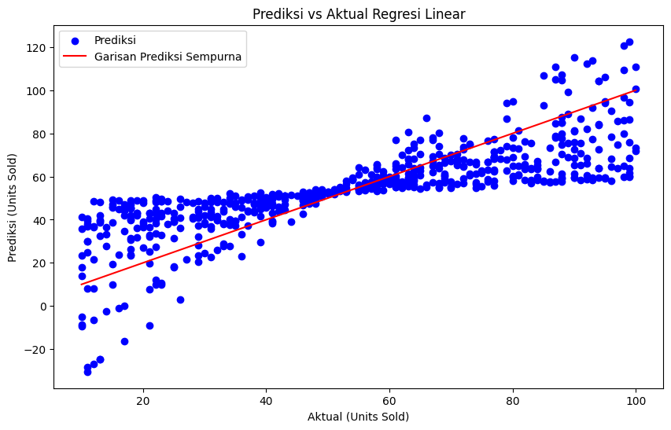

```python
# Visualisasi Prediksi vs Aktual
    plt.figure(figsize=(10,6))
    plt.scatter(y_test, y_pred, color='blue', label='Prediksi')
    plt.plot([min(y_test), max(y_test)], [min(y_test), max(y_test)], color='red', label='Garisan Prediksi Sempurna')
    plt.xlabel('Aktual (Units Sold)')
    plt.ylabel('Prediksi (Units Sold)')
    plt.title('Prediksi vs Aktual Regresi Linear')
    plt.legend()
    plt.show()
```

```python
# Menampilkan nilai aktual dan prediksi dalam format yang rapi
    for i in range(len(y_test)):
        print(f"Actual: {y_test.iloc[i]:.2f}, Predicted: {y_pred[i]:.2f}")
```

```
Actual: 66.00, Predicted: 87.20
    Actual: 49.00, Predicted: 51.40
    Actual: 48.00, Predicted: 51.88
    Actual: 73.00, Predicted: 74.86
    Actual: 77.00, Predicted: 63.15
    Actual: 77.00, Predicted: 68.86
    Actual: 46.00, Predicted: 49.09
    Actual: 19.00, Predicted: 31.68
    Actual: 84.00, Predicted: 58.21
    Actual: 23.00, Predicted: 10.08
    Actual: 20.00, Predicted: 37.08
    Actual: 100.00, Predicted: 100.72
    Actual: 30.00, Predicted: 38.76
    Actual: 36.00, Predicted: 41.28
    Actual: 29.00, Predicted: 43.96
    Actual: 37.00, Predicted: 49.74
    Actual: 70.00, Predicted: 57.54
    Actual: 55.00, Predicted: 54.35
    Actual: 51.00, Predicted: 53.82
    Actual: 42.00, Predicted: 51.43
    Actual: 67.00, Predicted: 78.21
    Actual: 93.00, Predicted: 113.69
    Actual: 41.00, Predicted: 50.41
    Actual: 88.00, Predicted: 57.68
    Actual: 81.00, Predicted: 60.82
    Actual: 30.00, Predicted: 37.85
    Actual: 48.00, Predicted: 52.41
    Actual: 31.00, Predicted: 41.15
    Actual: 17.00, Predicted: 42.02
    Actual: 61.00, Predicted: 57.58
    Actual: 69.00, Predicted: 60.20
    Actual: 81.00, Predicted: 60.47
    Actual: 48.00, Predicted: 47.45
    Actual: 43.00, Predicted: 49.44
    Actual: 63.00, Predicted: 68.40
    Actual: 64.00, Predicted: 62.21
    Actual: 88.00, Predicted: 77.87
    Actual: 36.00, Predicted: 33.09
    Actual: 91.00, Predicted: 86.79
    Actual: 64.00, Predicted: 59.73
```

[output cut: 570 more lines]

```
    Actual: 31.00, Predicted: 48.07
    Actual: 68.00, Predicted: 55.00
    Actual: 94.00, Predicted: 59.54
    Actual: 77.00, Predicted: 68.31
    Actual: 87.00, Predicted: 77.90
    Actual: 25.00, Predicted: 17.91
    Actual: 36.00, Predicted: 23.11
    Actual: 57.00, Predicted: 60.78
    Actual: 25.00, Predicted: 18.24
    Actual: 41.00, Predicted: 51.72
    Actual: 69.00, Predicted: 58.08
    Actual: 38.00, Predicted: 47.27
    Actual: 42.00, Predicted: 43.86
    Actual: 34.00, Predicted: 49.85
    Actual: 71.00, Predicted: 65.15
```

## Random Forest

```python
from sklearn.ensemble import RandomForestRegressor
    from sklearn.metrics import mean_squared_error, r2_score
    import numpy as np

    # Menentukan model Random Forest
    model_rf = RandomForestRegressor(n_estimators=100, random_state=42)

    # Melatih model menggunakan data training
    model_rf.fit(X_train, y_train)

    # Melakukan prediksi pada data testing
    y_pred_rf = model_rf.predict(X_test)

    # Menghitung RMSE (Root Mean Squared Error)
    rmse_rf = mean_squared_error(y_test, y_pred_rf, squared=False)

    # Menghitung R-squared (koefisien determinasi)
    r_squared_rf = r2_score(y_test, y_pred_rf)

    # Menghitung MAPE (Mean Absolute Percentage Error)
    mape_rf = np.mean(np.abs((y_test - y_pred_rf) / y_test)) * 100

    # Menampilkan hasil evaluasi
    print(f"RMSE (Random Forest): {rmse_rf}")
    print(f"R-squared (Random Forest): {r_squared_rf}")
    print(f"MAPE (Random Forest): {mape_rf}%")

    # Menampilkan nilai aktual dan prediksi dengan format yang rapi
    for i in range(len(y_test)):
        print(f"Actual: {y_test.iloc[i]:.2f}, Predicted: {y_pred_rf[i]:.2f}")
```

```
RMSE (Random Forest): 0.9464270494866469
    R-squared (Random Forest): 0.9986651404217923
    MAPE (Random Forest): 1.6486887985164296%
    Actual: 66.00, Predicted: 65.52
    Actual: 49.00, Predicted: 49.15
    Actual: 48.00, Predicted: 48.04
    Actual: 73.00, Predicted: 72.39
    Actual: 77.00, Predicted: 79.14
    Actual: 77.00, Predicted: 76.92
    Actual: 46.00, Predicted: 45.46
    Actual: 19.00, Predicted: 18.42
    Actual: 84.00, Predicted: 87.67
    Actual: 23.00, Predicted: 23.13
    Actual: 20.00, Predicted: 20.82
    Actual: 100.00, Predicted: 96.14
    Actual: 30.00, Predicted: 30.00
    Actual: 36.00, Predicted: 35.12
    Actual: 29.00, Predicted: 29.34
    Actual: 37.00, Predicted: 37.61
    Actual: 70.00, Predicted: 71.92
    Actual: 55.00, Predicted: 54.80
    Actual: 51.00, Predicted: 48.62
    Actual: 42.00, Predicted: 39.64
    Actual: 67.00, Predicted: 66.15
    Actual: 93.00, Predicted: 91.35
    Actual: 41.00, Predicted: 40.00
    Actual: 88.00, Predicted: 88.94
    Actual: 81.00, Predicted: 84.77
    Actual: 30.00, Predicted: 29.66
    Actual: 48.00, Predicted: 49.74
    Actual: 31.00, Predicted: 30.99
    Actual: 17.00, Predicted: 16.82
    Actual: 61.00, Predicted: 61.74
    Actual: 69.00, Predicted: 68.78
    Actual: 81.00, Predicted: 82.90
    Actual: 48.00, Predicted: 48.16
    Actual: 43.00, Predicted: 42.45
    Actual: 63.00, Predicted: 63.80
    Actual: 64.00, Predicted: 64.07
    Actual: 88.00, Predicted: 87.70
```

[output cut: 573 more lines]

```
    Actual: 31.00, Predicted: 31.50
    Actual: 68.00, Predicted: 66.60
    Actual: 94.00, Predicted: 95.54
    Actual: 77.00, Predicted: 76.91
    Actual: 87.00, Predicted: 87.49
    Actual: 25.00, Predicted: 25.14
    Actual: 36.00, Predicted: 36.06
    Actual: 57.00, Predicted: 56.93
    Actual: 25.00, Predicted: 25.17
    Actual: 41.00, Predicted: 40.31
    Actual: 69.00, Predicted: 69.71
    Actual: 38.00, Predicted: 38.25
    Actual: 42.00, Predicted: 42.27
    Actual: 34.00, Predicted: 34.76
    Actual: 71.00, Predicted: 70.59
```

[figure not shown]

```python
import matplotlib.pyplot as plt

    # Visualisasi Prediksi vs Aktual Random Forest
    plt.figure(figsize=(10,6))
    plt.scatter(y_test, y_pred, color='blue', label='Prediksi')
    plt.plot([min(y_test), max(y_test)], [min(y_test), max(y_test)], color='red', label='Garisan Prediksi Sempurna')
    plt.xlabel('Aktual (Units Sold)')
    plt.ylabel('Prediksi (Units Sold)')
    plt.title('Prediksi vs Aktual Random Forest')
    plt.legend()
    plt.show()
```

## Support Vector Regression

```python
from sklearn.svm import SVR
    from sklearn.metrics import mean_squared_error, r2_score
    import numpy as np

    # Menentukan model SVR dengan kernel RBF
    model_svr = SVR(kernel='rbf', C=1.0, epsilon=0.1)

    # Melatih model menggunakan data training
    model_svr.fit(X_train, y_train)

    # Melakukan prediksi pada data testing
    y_pred_svr = model_svr.predict(X_test)

    # Menghitung RMSE (Root Mean Squared Error)
    rmse_svr = mean_squared_error(y_test, y_pred_svr, squared=False)

    # Menghitung R-squared (koefisien determinasi)
    r_squared_svr = r2_score(y_test, y_pred_svr)

    # Menghitung MAPE (Mean Absolute Percentage Error)
    mape_svr = np.mean(np.abs((y_test - y_pred_svr) / y_test)) * 100

    # Menampilkan hasil evaluasi
    print(f"RMSE (SVR): {rmse_svr}")
    print(f"R-squared (SVR): {r_squared_svr}")
    print(f"MAPE (SVR): {mape_svr}%")

    # Menampilkan nilai aktual dan prediksi dengan format yang rapi
    for i in range(len(y_test)):
        print(f"Actual: {y_test.iloc[i]:.2f}, Predicted: {y_pred_svr[i]:.2f}")
```

```
RMSE (SVR): 22.407101804773237
    R-squared (SVR): 0.25177421880734496
    MAPE (SVR): 47.43694045800564%
    Actual: 66.00, Predicted: 82.07
    Actual: 49.00, Predicted: 65.38
    Actual: 48.00, Predicted: 52.31
    Actual: 73.00, Predicted: 68.40
    Actual: 77.00, Predicted: 52.47
    Actual: 77.00, Predicted: 64.38
    Actual: 46.00, Predicted: 61.77
    Actual: 19.00, Predicted: 38.20
    Actual: 84.00, Predicted: 36.84
    Actual: 23.00, Predicted: 59.27
    Actual: 20.00, Predicted: 36.13
    Actual: 100.00, Predicted: 70.83
    Actual: 30.00, Predicted: 46.29
    Actual: 36.00, Predicted: 55.33
    Actual: 29.00, Predicted: 38.52
    Actual: 37.00, Predicted: 33.77
    Actual: 70.00, Predicted: 41.53
    Actual: 55.00, Predicted: 55.94
    Actual: 51.00, Predicted: 32.02
    Actual: 42.00, Predicted: 31.01
    Actual: 67.00, Predicted: 70.87
    Actual: 93.00, Predicted: 82.07
    Actual: 41.00, Predicted: 38.43
    Actual: 88.00, Predicted: 37.40
    Actual: 81.00, Predicted: 44.25
    Actual: 30.00, Predicted: 46.29
    Actual: 48.00, Predicted: 41.98
    Actual: 31.00, Predicted: 47.02
    Actual: 17.00, Predicted: 31.01
    Actual: 61.00, Predicted: 46.79
    Actual: 69.00, Predicted: 52.85
    Actual: 81.00, Predicted: 44.25
    Actual: 48.00, Predicted: 72.98
    Actual: 43.00, Predicted: 49.53
    Actual: 63.00, Predicted: 68.32
    Actual: 64.00, Predicted: 65.09
    Actual: 88.00, Predicted: 68.43
```

[output cut: 573 more lines]

```
    Actual: 31.00, Predicted: 31.25
    Actual: 68.00, Predicted: 34.04
    Actual: 94.00, Predicted: 38.26
    Actual: 77.00, Predicted: 64.38
    Actual: 87.00, Predicted: 68.41
    Actual: 25.00, Predicted: 59.01
    Actual: 36.00, Predicted: 68.10
    Actual: 57.00, Predicted: 68.34
    Actual: 25.00, Predicted: 59.01
    Actual: 41.00, Predicted: 34.66
    Actual: 69.00, Predicted: 49.68
    Actual: 38.00, Predicted: 46.63
    Actual: 42.00, Predicted: 62.08
    Actual: 34.00, Predicted: 31.73
    Actual: 71.00, Predicted: 62.57
```

[figure not shown]

```python
import matplotlib.pyplot as plt

    # Visualisasi Prediksi vs Aktual SVR
    plt.figure(figsize=(10,6))
    plt.scatter(y_test, y_pred, color='blue', label='Prediksi')
    plt.plot([min(y_test), max(y_test)], [min(y_test), max(y_test)], color='red', label='Garisan Prediksi Sempurna')
    plt.xlabel('Aktual (Units Sold)')
    plt.ylabel('Prediksi (Units Sold)')
    plt.title('Prediksi vs Aktual Random SVR')
    plt.legend()
    plt.show()
```

# Prediksi

```python
import pandas as pd

    # Meminta input dari pengguna
    unit_price = float(input("Masukkan Unit_Price (Harga per unit): "))
    total_revenue = float(input("Masukkan Total_Revenue (Total Pendapatan): "))

    # Meminta input untuk Units_Sold_Lag_1 hingga Units_Sold_Lag_7
    units_sold_lags = []
    for i in range(1, 8):
        units_sold_lag = float(input(f"Masukkan Units_Sold_Lag_{i} (Unit Terjual {i} hari yang lalu): "))
        units_sold_lags.append(units_sold_lag)

    # Buat DataFrame dari input pengguna
    new_input = pd.DataFrame({
        'Unit_Price': [unit_price],
        'Total_Revenue': [total_revenue],
        'Units_Sold_Lag_1': [units_sold_lags[0]],
        'Units_Sold_Lag_2': [units_sold_lags[1]],
        'Units_Sold_Lag_3': [units_sold_lags[2]],
        'Units_Sold_Lag_4': [units_sold_lags[3]],
        'Units_Sold_Lag_5': [units_sold_lags[4]],
        'Units_Sold_Lag_6': [units_sold_lags[5]],
        'Units_Sold_Lag_7': [units_sold_lags[6]]
    })

    # Menampilkan data input pengguna
    print("\nData Input dari Pengguna:")
    print(new_input)

    # Prediksi jumlah unit yang terjual
    predicted_units_sold = model_rf.predict(new_input)

    # Menampilkan hasil prediksi
    print(f"\nPrediksi jumlah unit yang akan terjual: {predicted_units_sold[0]:.2f}")
```

```
Masukkan Unit_Price (Harga per unit): 20000
    Masukkan Total_Revenue (Total Pendapatan): 1000000
    Masukkan Units_Sold_Lag_1 (Unit Terjual 1 hari yang lalu): 50
    Masukkan Units_Sold_Lag_2 (Unit Terjual 2 hari yang lalu): 20
    Masukkan Units_Sold_Lag_3 (Unit Terjual 3 hari yang lalu): 40
    Masukkan Units_Sold_Lag_4 (Unit Terjual 4 hari yang lalu): 60
    Masukkan Units_Sold_Lag_5 (Unit Terjual 5 hari yang lalu): 18
    Masukkan Units_Sold_Lag_6 (Unit Terjual 6 hari yang lalu): 10
    Masukkan Units_Sold_Lag_7 (Unit Terjual 7 hari yang lalu): 20

    Data Input dari Pengguna:
       Unit_Price  Total_Revenue  Units_Sold_Lag_1  Units_Sold_Lag_2  \
    0     20000.0      1000000.0              50.0              20.0

       Units_Sold_Lag_3  Units_Sold_Lag_4  Units_Sold_Lag_5  Units_Sold_Lag_6  \
    0              40.0              60.0              18.0              10.0

       Units_Sold_Lag_7
    0              20.0

    Prediksi jumlah unit yang akan terjual: 50.24
```

# Evaluasi

```python
import pandas as pd

    # Membuat data model dan hasil evaluasi
    data = {
        'Model': ['Linear Regression', 'Random Forest', 'SVR'],
        'RMSE': [15.53, 0.95, 22.41],
        'R-squared': [0.6406, 0.9987, 0.251],
        'MAPE': ['38.59%', '1.65%', '47.44%']
    }

    # Membuat DataFrame
    df = pd.DataFrame(data)

    # Menampilkan tabel
    df
```

|  | Model | RMSE | R-squared | MAPE |
| --- | --- | --- | --- | --- |
| 0 | Linear Regression | 15.53 | 0.6406 | 38.59% |
| 1 | Random Forest | 0.95 | 0.9987 | 1.65% |
| 2 | SVR | 22.41 | 0.2510 | 47.44% |

# Kesimpulan

1. Random Forest jelas memiliki performa terbaik di antara ketiga model dengan RMSE yang sangat rendah (0.95), R-squared yang sangat tinggi (0.9987), dan MAPE yang sangat kecil (1.65%). Ini menunjukkan bahwa model ini mampu memberikan prediksi yang sangat akurat dan dapat diandalkan.
2. Linear Regression memiliki performa yang lebih buruk dibandingkan Random Forest, dengan RMSE yang jauh lebih tinggi dan MAPE yang cukup besar. Meskipun R-squared lebih tinggi dari SVR, hasilnya masih jauh di bawah Random Forest.
3. SVR memiliki performa yang paling buruk dengan R-squared yang sangat rendah, RMSE yang tinggi, dan MAPE yang juga sangat besar. Model ini tampaknya tidak cocok untuk dataset ini.